# Lab1 Flotte Tunisair

Groupe1-4DS2

15 octobre 2018

# COMPREHENSION METIER:

## Informations relatives aux objectifs Métier :

### Flotte de Tunisair:

La moyenne d’âge des avions de Tunisair est de 15 ans . Actuellement elle possède une flotte opérationnelle de 29 appareils en exploitation, dont 22 Airbus et 7 Boeing. En regardant ces appareils de plus près, on peut constater que ces différents appareils ont été acquis entre 1999 et 2015 . A noter également qu’aucun avion n’a été acheté avant la période entre 2015. Ce qui nous amène à nous questionner sur la qualité matérielle des appareils les plus âgés. Sécurité: Tunisair est classée selon l’observatoire aérien et du tourisme parmi les compagnies les plus sures du monde devançant ainsi toutes les autres compagnies africaines. Concurrence: Beaucoup ont vu d’un oil pessimiste la signature de l’accord de l’Open Sky prétextant que cette compagnie n’était pas encore prête. Pourtant qui dit Open Sky dit plus de voyageurs et plus de parts de marché à acquérir. Quels sont les raisons de ce pessimisme? Quels sont les principaux concurrents actuels de Tunisair? Existent-t-ils des normes qui pourrait entrer en jeux dans la concurrence que l’Open Sky a à offrir? Selon le site d’info Kapitalys «la Tunisie n’est jamais arrivée à exploiter plus de 35% des parts de marché qui lui revenait de droit , et ce en raison de moyens logistiques et financiers très faibles . Selon la même source, le taux de remplissage des sièges est de 70% , ce qui met Tunisair plus en difficulté vu que qu’elle va devoir faire face à des concurrents plus puissants financièrement et mieux équipés qui pourront très facilement imposer leur prix. Pourtant des succès stories relatives à l’Open Sky ont bel se sont bel et bien produites, on peut citer par exemple: «Royal Air Maroc» , «Turkish Airlines» et bien d’autres . C’est tout simplement parce qu’une plus grande concurrence incite les compagnies à baisser fortement les prix, ce qui a pour conséquence immédiate et mécanique de faire augmenter la demande. La concurrence oblige les uns et les autres à soigner de manière plus rigoureuse leur qualité de service et le confort des passagers, s’ils veulent préserver leurs parts de marchés. Les principaux concurrents régionaux de Tunisair sont principalement issus du Maroc, d’Algérie, de l’Egypte. On peut également citer Syphax et Nouvelair qui sont des compagnies locale. Pour ce qui est des concurrents internationaux , ces concurrents nous viennent principalement des pays du golfe , de l’Asie , d’Europe et d’Afrique .

En nous intéressant à ces différentes compagnies Low-Cost, on peut déjà remarquer que l’atout majeure de ces compagnies est un nombre important d’avions , toujours plus confortables et à la pointe de la technologie qui consomment de moins en moins de carburant . Par exemple rien qu’en 2013 Turkish Airlines a commandé 117 Airbus et 95 Boeing (d’après la tribune.fr) On pourrait également nous tourner vers des sites et applications de voyage tel que Trip-Advisor ou encore Flight-report et essayer de récolter données d’avis d’utilisateurs sur TunisAir pour savoir si elle répond aux exigences des voyageurs . Comme mentionné tout à l’heure, Tunis Air souffre de nos jours d’un grand problème de retards répétitifs. En essayant de chercher la cause de ses retards, on constate que dans la majeure partie des cas, cela est dû à des problèmes techniques. Cela nous ramène à nous questionner encore une fois sur la qualité des avions qu’elle compte au sein de sa flotte. Sachant que le temps pour les voyageurs est d’une importance capitale, nous devrions peut-être essayer de collecter des données pour savoir TunisAir arrive encore à répondre aux exigences de ses clients en terme de temps. Enfin, dans cette même optique , peut être devrions nous collecter des données sur des destinations desservies par TunisAir , et essayer de comparer la durée du trajet avec d’autre compagnies pour pouvoir conclure convenablement . ##Data science goals

Pour trouver des solutions stratégiques à Tunisair , Nous allons essayer de comprendre sur quoi se basent les utilisateurs en attribuant une note à une compagnie. Pour ce faire nous ferons appel à la technique d’apprentissage automatique appelée foret d arbre decisionnels .

## Compréhension des données

Lors de la phase de la compréhension des données, nous nous intéressons aux données mises à notre disposition et à leur lien avec notre problématique. Notre jeu de données est un jeu de données qui porte sur les avions avec leurs compagnies aériennes. Les fichiers Long_haul_Economy.csv , Short_haul_Economy.csv et Short_haul_First_Business nous renseigne sur les équipements q’on peut trouver dans les avions classés par classe et par type de vol. Pour ce qui est du fichier aireline-safety.csv , il renseigne sur les accidents et les fatalités qui se sont produits lors des dernières années chez plusieurs compagnies aériennes de renommé. Pour étudier les retards des avions du à des problèmes technique, on a pu scrappé les commentaires des utilisateurs sur Tunisair du site [airlinequality] (https://www.airlinequality.com/airline-reviews/tunisair/) dans un fichier “testcloud.txt” à partir du code python du fichier ReviewsScrapingAirTrax.ipynb . Nous avons également eu besoin d’un data set que nous avons obtenu en scrappant les avis d’utilisateurs à partir du site “AIRTRAX” , qui est une pointure dans la récolte des avis des utilisateurs sur les compagnies aeriennes . Ce dataset contient une des notes attribuées par les voyageurs dans plusieurs domaines , telque le rapport qualité prix , l confort des sieges , la nourriture, etc. Pour dégager le profil typique d’avion dans le monde, on a utilisé le dataset “FAA Aircraft Characteristics.csv” contenant les avions déclarés par l’FAA.

```r
library(xlsx)
reviews=read.xlsx("ReviewsScrapingAirTrax1.xlsx",sheetName = "Feuil1")
str(reviews)
```

```
## 'data.frame':    9232 obs. of  16 variables:
##  $ airline        : Factor w/ 19 levels "Air Algerie",..: 18 18 18 18 18 18 18 18 18 18 ...
##  $ overall        : num  1 9 1 1 1 1 2 7 6 8 ...
##  $ author         : Factor w/ 7252 levels "A Abdelbadee",..: 451 6146 4763 6901 1973 6447 1013 106 1401 6266 ...
##  $ review_date    : Factor w/ 2143 levels "10th April 2012",..: 803 979 1778 76 1266 1683 1236 1762 1893 2002 ...
##  $ aircraft       : Factor w/ 661 levels "319","320/321",..: NA 14 NA NA NA 32 32 32 372 32 ...
##  $ traveller_type : Factor w/ 4 levels "Business","Couple Leisure",..: 4 4 1 2 2 2 1 2 4 3 ...
##  $ cabin          : Factor w/ 4 levels "Business Class",..: 2 2 2 2 2 2 2 1 2 2 ...
##  $ route          : Factor w/ 4157 levels "ÃÂ°stanbul to Antalya",..: 3958 3963 824 1088 833 3960 2697 3951 574 2480 ...
##  $ date_flown     : Factor w/ 51 levels "April 2015","April 2016",..: 9 30 30 34 50 13 8 15 41 41 ...
##  $ seat_comfort   : num  1 4 5 1 1 1 3 4 3 5 ...
##  $ cabin_service  : num  1 5 5 1 2 1 3 4 4 5 ...
##  $ food_bev       : num  1 5 5 1 1 1 NA 1 3 5 ...
##  $ entertainment  : num  1 NA 5 1 1 NA NA NA 1 NA ...
##  $ ground_service : num  1 4 5 1 1 1 1 1 3 3 ...
##  $ value_for_money: num  1 5 5 1 1 4 1 4 4 5 ...
##  $ recommended    : Factor w/ 2 levels "no","yes": 1 2 1 1 1 1 1 2 2 2 ...
```

```r
colnames(reviews)
```

```
##  [1] "airline"         "overall"         "author"
##  [4] "review_date"     "aircraft"        "traveller_type"
##  [7] "cabin"           "route"           "date_flown"
## [10] "seat_comfort"    "cabin_service"   "food_bev"
## [13] "entertainment"   "ground_service"  "value_for_money"
## [16] "recommended"
```

```r
summary(reviews)
```

```
##              airline        overall                   author
##  Emirates        :1630   Min.   : 1.000   Anders Pedersen:  48
##  Turkish Airlines:1331   1st Qu.: 3.000   H Mutschler    :  23
##  Qatar Airways   :1319   Median : 7.000   T Eldem        :  20
##  Lufthansa       :1310   Mean   : 5.871   Michel Perrin  :  19
##  Air France      : 612   3rd Qu.: 9.000   Derek Salter   :  17
##  Alitalia        : 593   Max.   :10.000   E Simeone      :  16
##  (Other)         :2437   NA's   :240      (Other)        :9089
##              review_date               aircraft           traveller_type
##  19th January 2015 :  37   A380            : 500   Business      :1026
##  4th March 2015    :  35   A320            : 214   Couple Leisure:1311
##  6th September 2014:  32   Boeing 777      : 174   Family Leisure: 927
##  14th January 2015 :  30   Boeing 777-300ER: 171   Solo Leisure  :1974
##  28th October 2014 :  30   A330            : 164   NA's          :3994
##  17th March 2015   :  27   (Other)         :2160
##  (Other)           :9041   NA's            :5849
##              cabin                         route
##  Business Class :2181   Seattle to Frankfurt  :  19
##  Economy Class  :6489   Toronto to Frankfurt  :  13
##  First Class    : 200   Dubai to Manchester   :   9
##  Premium Economy: 295   LHR to BKK via DOH    :   9
##  NA's           :  67   Baltimore to Frankfurt:   8
##                         (Other)               :5177
##                         NA's                  :3997
##           date_flown    seat_comfort   cabin_service      food_bev
##  January 2016  : 192   Min.   :1.000   Min.   :1.000   Min.   :1.000
##  August 2015   : 190   1st Qu.:2.000   1st Qu.:2.000   1st Qu.:2.000
##  September 2015: 178   Median :4.000   Median :4.000   Median :4.000
##  December 2015 : 173   Mean   :3.315   Mean   :3.459   Mean   :3.323
##  July 2015     : 167   3rd Qu.:4.000   3rd Qu.:5.000   3rd Qu.:5.000
##  (Other)       :4322   Max.   :5.000   Max.   :5.000   Max.   :5.000
##  NA's          :4010   NA's   :663     NA's   :665     NA's   :1009
##  entertainment   ground_service value_for_money recommended
##  Min.   :1.000   Min.   :1.00   Min.   :1.000   no :3997
##  1st Qu.:2.000   1st Qu.:1.00   1st Qu.:2.000   yes:5235
##  Median :4.000   Median :3.00   Median :4.000
##  Mean   :3.425   Mean   :3.01   Mean   :3.293
##  3rd Qu.:5.000   3rd Qu.:4.00   3rd Qu.:5.000
##  Max.   :5.000   Max.   :5.00   Max.   :5.000
##  NA's   :1928    NA's   :4033   NA's   :79
```

```r
dim(reviews)
```

```
## [1] 9232   16
```

Dans la partie Flotte age , dimension et valeur, nous avons besoin de visualiser les données afin de les comprendre: une bonne analyse nous permettons de déterminer les grands points et aiser la phase de la preparation des données pour ce là on va utiliser tableau

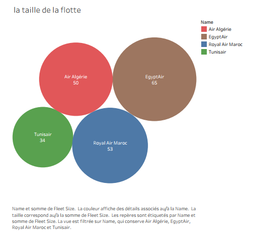

[figure not shown]

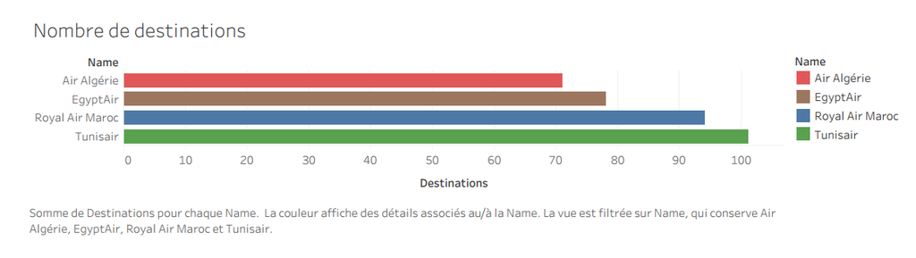

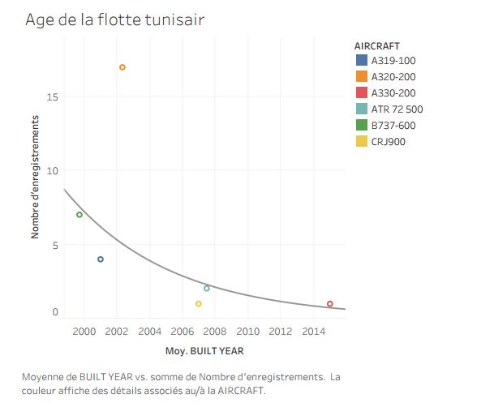

# Préparation des données:

Comme mentionné précedemment on a des fichiers csv des équipements des avions par compagnie aérienne, par le type du vol et le type du classe donc on a tiré seleument les équipements dont on souhaite analyser et qui sont le type Video, Laptop Power,Power Type,Wi-Fi et le type du siège. Afin de mieux analyser les accidents recourus j’ai joué que sur ceux qui se sont produits entre les années 2000 et 2014. Le dataset contient beaucoup de données manquantes (des champs “tbd”, “No Value”, “#VALUE!”, etc.) On a remplacé tout ces valeurs par la valeur moyenne en cas des valeurs réelles et la médiane en cas des valeurs entières. Mais cette correction a été rejetée car les données deviennent biaisées. On a éliminé les valeurs qualitatives pour appliquer les algorithmes de segmentation.

```r
library(arules)
Short_haul_economy_Classtotal = read.csv("Short_haul_Economy.csv",sep=";")
f3=Short_haul_economy_Classtotal[which(Short_haul_economy_Classtotal$Airline=="Tunis Air"),]
Short_haul_economyTunisair=f3[,c(5:9)]
write.table(Short_haul_economyTunisair, "Short_haul_Economy_ClassTunisair.csv", sep=",",quote = FALSE,row.names = FALSE)
Short_haul_economyecrire = Short_haul_economy_Classtotal[,c(5:9)]
write.table(Short_haul_economyecrire, "Short_haul_Economy_Class2.csv", sep=",",quote = FALSE,row.names = FALSE)
Short_haul_Economy_Class = read.transactions("Short_haul_Economy_Class2.csv",sep=";",skip = 1)
Short_haul_Economy_Classtunisair = read.transactions("Short_haul_Economy_ClassTunisair.csv",sep=";",skip = 1)
```

```r
Short_haul_First_Classtotal = read.csv("Short_haul_First_Business.csv",sep=";")
f=Short_haul_First_Classtotal[which(Short_haul_First_Classtotal$Airline=="Tunis Air"),]
Short_haul_First_BusinessTunisair=f[,c(5:9)]
write.table(Short_haul_First_BusinessTunisair, "Short_haul_First_BusinessTunisair.csv", sep=",",quote = FALSE,row.names = FALSE)
Short_haul_First_Businessecrire = Short_haul_First_Classtotal[,c(5:9)]
write.table(Short_haul_First_Businessecrire, "Short_haul_First_Business2.csv", sep=",",quote = FALSE,row.names = FALSE)
Short_haul_First_Class = read.transactions("Short_haul_First_Business2.csv",sep=";",skip = 1)
Short_haul_First_ClassTunisair = read.transactions("Short_haul_First_BusinessTunisair.csv",sep=";",skip = 1)
```

```r
long_haul_economyTotal = read.csv("Long_haul_Economy.csv",sep=";")
f2=long_haul_economyTotal[which(long_haul_economyTotal$Airline=="Tunis Air"),]
long_haul_economyTunisair=f2[,c(5:9)]
write.table(long_haul_economyTunisair, "long_haul_economyTunisair.csv", sep=",",quote = FALSE,row.names = FALSE)
long_haul_economyTunisairecrire = long_haul_economyTotal[,c(5:9)]
write.table(long_haul_economyTunisairecrire, "long_haul_economy2.csv", sep=",",quote = FALSE,row.names = FALSE)
long_haul_economy = read.transactions("long_haul_economy2.csv",sep=";",skip = 1)
long_haul_economy_ClassTunisair = read.transactions("long_haul_economyTunisair.csv",sep=";",skip = 1)
```

Dans la partie Flotte age , dimension et valeur nous avons utilisé tableau pour l’agrégation et le groupement des données et R pour le netoyage.

```r
library(xlsx)

data = read.csv("FAA Aircraft Characteristics.csv",header=T,sep=",",dec=".",na.string="")
summary(data)
```

```
##      Date.Completed                     Manufacturer
##  tbd        : 163   Boeing                    : 113
##  2016-Jul-1 :  44   Piper                     : 104
##  2016-Sep-6 :  38   Cessna                    :  83
##  2017-Nov-2 :  28   Boeing (McDonnell Douglas):  69
##  2017-Sep-15:  27   Beechcraft                :  61
##  (Other)    : 573   Embraer                   :  58
##  NA's       :1891   (Other)                   :2276
##               Model      Physical.Class..Engine. X..Engines
##  BK-117          :   5   tbd      :1831          0  :   1
##  223 Flamingo    :   4   Piston   : 398          1  : 323
##  CM-170R Magister:   4   Jet      : 388          2  : 437
##  Jaguar          :   4   Turboprop: 143          3  :  10
##  Metro           :   4   Electric :   1          4  :  37
##  Myst            :   4   Glider   :   1          tbd:1956
##  (Other)         :2739   (Other)  :   2
##        AAC             ADG            TDG       Approach.Speed..Vref.
##  A       : 308   No Value:1899   tbd    :2036   Min.   : 30.0
##  B       : 205   I       : 361   1A     : 324   1st Qu.: 77.0
##  C       : 258   III     : 193   2      : 119   Median :107.0
##  D       :  78   II      : 182   1B     : 102   Mean   :104.2
##  E       :   4   IV      :  76   3      :  75   3rd Qu.:130.0
##  No Value:1911   V       :  39   5      :  53   Max.   :230.0
##                  (Other) :  14   (Other):  55   NA's   :1911
##     Wingtip.Configuration  Wingspan..ft    Length..ft
##  tbd           :2023      35.00  :  17   tbd    :2024
##  no winglets   : 494      30.00  :  14   35.50  :  13
##  winglets      : 155      36.00  :  14   23.00  :  10
##  tip tanks     :  39      142.40 :  12   187.40 :   8
##  wingtip fences:  11      36.08  :  11   23.50  :   8
##  none          :   9      (Other): 797   68.42  :   8
##  (Other)       :  33      NA's   :1899   (Other): 693
##  Tail.Height..ft....OEW. Wheelbase..ft  Cockpit.to.Main.Gear..CMG.
##  tbd    :1919            tbd    :2298   tbd    :2295
##  8.33   :  16            6.58   :  18   25.00  :  19
##  14.50  :  13            84.00  :  12   6.58   :  18
##  14.25  :  12            17.79  :  10   91.67  :  12
##  15.00  :  12            25.00  :   9   17.79  :  10
##  22.17  :  12            37.42  :   9   11.67  :   8
##  (Other): 780            (Other): 408   (Other): 402
```

[output cut: 25 more lines]

```
##  tbd                                                                                  :2742
##  ARJ21 = Advanced Regional Jet for the 21st Century                                   :   6
##  same dimensions as 560-E                                                             :   4
##  https://blog.wepushtin.com/blog/understanding-differences-hawker-800-series-aircraft/:   3
##  a 560-A                                                                              :   2
##  http://www.airbus.com/defence.html                                                   :   2
##  (Other)                                                                              :   5
##  Parking.Area..WS.x.Length...sf
##  #VALUE!:2024
##  4,401  :   8
##  45,362 :   7
##  6,444  :   7
##  1,539  :   6
##  1,784  :   6
##  (Other): 706
```

```r
  db=read.table("Fleet Data.csv",header = TRUE,sep = ",",na.strings = "")
  db$Unit.Cost=as.numeric(sub("\\$","",db$Unit.Cost))
  db$Total.Cost..Current.=as.numeric(sub("\\$","",sub(",","",db$Total.Cost..Current.)))
  db[is.na(db)]<- 0
  write.xlsx(db,"finalcleaneddata.xlsx")

  db5=read.table("c3data.csv",header = TRUE,sep = ";",na.strings = "",dec = ",")
    db5$Moy..Total.Cost..Current.=as.numeric(sub(",",".",sub(" ","",db5$Moy..Total.Cost..Current.)))
```

```r
data[data == "tbd" | data=="#VALUE!" | data=="No Value"] = NA
data1=data[,c(5,9,11,12,17,18)]
summary(data1)
```

```
##  X..Engines  Approach.Speed..Vref.  Wingspan..ft    Length..ft
##  0   :   1   Min.   : 30.0         35.00  :  17   35.50  :  13
##  1   : 323   1st Qu.: 77.0         30.00  :  14   23.00  :  10
##  2   : 437   Median :107.0         36.00  :  14   187.40 :   8
##  3   :  10   Mean   :104.2         142.40 :  12   23.50  :   8
##  4   :  37   3rd Qu.:130.0         36.08  :  11   68.42  :   8
##  tbd :   0   Max.   :230.0         (Other): 793   (Other): 693
##  NA's:1956   NA's   :1911          NA's   :1903   NA's   :2024
##       MTOW          Max.Ramp.Max.Taxi
##  12,500 :  12   same as MTOW?:  66
##  6,000  :  10   1,320        :   6
##  1,320  :   7   2,200        :   6
##  174,200:   7   same as MTOW :   6
##  2,400  :   7   3,400        :   5
##  (Other): 805   (Other)      : 594
##  NA's   :1916   NA's         :2081
```

```r
str(data1)
```

```
## 'data.frame':    2764 obs. of  6 variables:
##  $ X..Engines           : Factor w/ 6 levels "0","1","2","3",..: 2 2 2 2 2 2 3 3 3 2 ...
##  $ Approach.Speed..Vref.: num  56 60 46 49 49 56 98 95 109 61 ...
##  $ Wingspan..ft         : Factor w/ 378 levels "100.25","100.40",..: 68 77 74 98 102 68 207 207 361 178 ...
##  $ Length..ft           : Factor w/ 369 levels "100.17","101.67",..: 56 66 67 63 65 56 230 242 333 175 ...
##  $ MTOW                 : Factor w/ 541 levels "1,030","1,102",..: 13 20 6 5 1 13 446 456 428 271 ...
##  $ Max.Ramp.Max.Taxi    : Factor w/ 426 levels "1,030","1,102",..: 16 16 4 3 1 10 346 351 329 205 ...
```

```r
data1[data1 == "tbd" | data1=="#VALUE!" | data1=="No Value"] = NA
data1$X..Engines =as.numeric(data1$X..Engines)
data1[data1 == "tbd" | data1=="same as 680F" | data1=="same WS as PA-28-235"] = NA
data1$Wingspan..ft =as.numeric(data1$Wingspan..ft)
data1[data1 == "tbd" | data1=="stretched 680F"] = NA
data1$Length..ft =as.numeric(data1$Length..ft)
data1$MTOW =as.numeric(data1$MTOW)
data1$Max.Ramp.Max.Taxi =as.numeric(data1$Max.Ramp.Max.Taxi)
data1=na.omit(data1)
```

Par la suite nous créons le dataframe reviews.forest qui contiendra les principales variables qui peuvent influencer le choix de la note attribuées par les utilisateurs

```r
reviews$overall=as.factor(reviews$overall)
reviews$seat_comfort=as.factor(reviews$seat_comfort)
reviews$cabin_service=as.factor(reviews$cabin_service)
reviews$food_bev=as.factor(reviews$food_bev)
reviews$entertainment=as.factor(reviews$entertainment)
reviews$ground_service=as.factor(reviews$ground_service)
reviews$value_for_money=as.factor(reviews$value_for_money)
reviews$recommended=as.factor(reviews$recommended)
```

```r
reviews.forest=reviews
reviews.forest$author=NULL
reviews.forest$review_date=NULL
reviews.forest$aircraft=NULL
reviews.forest$route=NULL
reviews.forest$date_flown=NULL
reviews.forest$recommended=NULL
reviews.forest$airline=NULL
colnames(reviews.forest)
```

```
## [1] "overall"         "traveller_type"  "cabin"           "seat_comfort"
## [5] "cabin_service"   "food_bev"        "entertainment"   "ground_service"
## [9] "value_for_money"
```

# MODELISATION et Evaluation:

## ANALYSE DES EXIGENCES DE CONFORT :

### Short-haul Economy Class

```r
rules = apriori(Short_haul_Economy_Class, parameter=list(support=0.0001, confidence=0.00001));
```

```
## Apriori
##
## Parameter specification:
##  confidence minval smax arem  aval originalSupport maxtime support minlen
##       1e-05    0.1    1 none FALSE            TRUE       5   1e-04      1
##  maxlen target   ext
##      10  rules FALSE
##
## Algorithmic control:
##  filter tree heap memopt load sort verbose
##     0.1 TRUE TRUE  FALSE TRUE    2    TRUE
##
## Absolute minimum support count: 0
##
## set item appearances ...[0 item(s)] done [0.00s].
## set transactions ...[30 item(s), 784 transaction(s)] done [0.00s].
## sorting and recoding items ... [30 item(s)] done [0.00s].
## creating transaction tree ... done [0.00s].
## checking subsets of size 1 done [0.00s].
## writing ... [30 rule(s)] done [0.00s].
## creating S4 object  ... done [0.00s].
```

```r
inspect(rules)
```

```
##      lhs    rhs                                                   support  confidence lift count
## [1]  {}  => {Overhead TV,None,AC Power,Yes,Standard}          0.001275510 0.001275510    1     1
## [2]  {}  => {Seatback TV,All Seats,AC Power,No,Standard}      0.001275510 0.001275510    1     1
## [3]  {}  => {None,All Seats,DC Power,Yes,Standard}            0.001275510 0.001275510    1     1
## [4]  {}  => {Seatback TV,None,AC Power,No,Standard}           0.002551020 0.002551020    1     2
## [5]  {}  => {Satellite TV,None,None,Yes,Standard}             0.002551020 0.002551020    1     2
## [6]  {}  => {Portable Device,None,None,Yes,Standard}          0.002551020 0.002551020    1     2
## [7]  {}  => {On-Demand TV,None,None,No,Recliner}              0.002551020 0.002551020    1     2
## [8]  {}  => {Seatback TV,None,None,Yes,Standard}              0.002551020 0.002551020    1     2
## [9]  {}  => {Portable Device,Some Seats,AC Power,No,Standard} 0.002551020 0.002551020    1     2
## [10] {}  => {None,Some Seats,AC Power,Yes,Standard}           0.003826531 0.003826531    1     3
## [11] {}  => {Satellite TV,All Seats,AC Power,Yes,Standard}    0.005102041 0.005102041    1     4
## [12] {}  => {Satellite TV,None,None,No,Standard}              0.005102041 0.005102041    1     4
## [13] {}  => {On-Demand TV,Some Seats,AC Power,No,Standard}    0.005102041 0.005102041    1     4
## [14] {}  => {Yes,All Seats,AC Power,Yes,Standard}             0.005102041 0.005102041    1     4
```

[output cut: 16 more lines]

```r
rulesTunisair = apriori(Short_haul_Economy_Classtunisair, parameter=list(support=0.1, confidence=0.1));
```

```
## Apriori
##
## Parameter specification:
##  confidence minval smax arem  aval originalSupport maxtime support minlen
##         0.1    0.1    1 none FALSE            TRUE       5     0.1      1
##  maxlen target   ext
##      10  rules FALSE
##
## Algorithmic control:
##  filter tree heap memopt load sort verbose
##     0.1 TRUE TRUE  FALSE TRUE    2    TRUE
##
## Absolute minimum support count: 0
##
## set item appearances ...[0 item(s)] done [0.00s].
## set transactions ...[1 item(s), 4 transaction(s)] done [0.00s].
## sorting and recoding items ... [1 item(s)] done [0.00s].
## creating transaction tree ... done [0.00s].
## checking subsets of size 1 done [0.00s].
## writing ... [1 rule(s)] done [0.00s].
## creating S4 object  ... done [0.00s].
```

```r
inspect(rulesTunisair)
```

```
##     lhs    rhs                          support confidence lift count
## [1] {}  => {None,None,None,No,Standard} 1       1          1    4
```

D’après les régles d’association de tous les compagnies aériennes des courts vols economique, on contate que la règle la plus récurante est {None,None,None,No,Standard}: la première valeur correspond à la variable Video Type , la deuxième au Laptop Power , la troixème au Power Type , la quatrième au Wi-Fi et la dernière au Seat Type. Cette règle est suivie par 338 compagnies. Et on constate aussi que Tunisair suit cette règle. Mais on voit que cette règle ne répond pas aux exigences.

### Short-haul First/Business

```r
rulesfirst = apriori(Short_haul_First_Class, parameter=list(support=0.001, confidence=0.001));
```

```
## Apriori
##
## Parameter specification:
##  confidence minval smax arem  aval originalSupport maxtime support minlen
##       0.001    0.1    1 none FALSE            TRUE       5   0.001      1
##  maxlen target   ext
##      10  rules FALSE
##
## Algorithmic control:
##  filter tree heap memopt load sort verbose
##     0.1 TRUE TRUE  FALSE TRUE    2    TRUE
##
## Absolute minimum support count: 0
##
## set item appearances ...[0 item(s)] done [0.00s].
## set transactions ...[43 item(s), 355 transaction(s)] done [0.00s].
## sorting and recoding items ... [43 item(s)] done [0.00s].
## creating transaction tree ... done [0.00s].
## checking subsets of size 1 done [0.00s].
## writing ... [43 rule(s)] done [0.00s].
## creating S4 object  ... done [0.00s].
```

```r
inspect(rulesfirst)
```

```
##      lhs    rhs                                                     support  confidence lift count
## [1]  {}  => {Overhead TV,None,AC Power,Yes,Recliner}            0.002816901 0.002816901    1     1
## [2]  {}  => {On-Demand TV,All Seats,AC Power,No,Flat Bed}       0.002816901 0.002816901    1     1
## [3]  {}  => {Portable Device,None,None,No,Standard}             0.002816901 0.002816901    1     1
## [4]  {}  => {Overhead TV,None,None,No,Angle Lie Flat}           0.002816901 0.002816901    1     1
## [5]  {}  => {On-Demand TV,All Seats,AC Power,Yes,Closed Suite}  0.002816901 0.002816901    1     1
## [6]  {}  => {Seatback TV,All Seats,AC Power,No,Angle Lie Flat}  0.002816901 0.002816901    1     1
## [7]  {}  => {Seatback TV,All Seats,AC Power,No,Flat Bed}        0.002816901 0.002816901    1     1
## [8]  {}  => {Seatback TV,None,None,No,Angle Lie Flat}           0.002816901 0.002816901    1     1
## [9]  {}  => {Seatback TV,None,None,Yes,Recliner}                0.002816901 0.002816901    1     1
## [10] {}  => {On-Demand TV,All Seats,AC Power,No,Angle Lie Flat} 0.002816901 0.002816901    1     1
## [11] {}  => {Portable Device,All Seats,AC Power,Yes,Flat Bed}   0.002816901 0.002816901    1     1
## [12] {}  => {None,All Seats,DC Power,Yes,Recliner}              0.002816901 0.002816901    1     1
## [13] {}  => {Seatback TV,All Seats,AC Power,Yes,Open Suite}     0.002816901 0.002816901    1     1
## [14] {}  => {Seatback TV,None,None,No,Standard}                 0.002816901 0.002816901    1     1
```

[output cut: 29 more lines]

```r
rulesfirsttunisair = apriori(Short_haul_First_ClassTunisair, parameter=list(support=0.01, confidence=0.01));
```

```
## Apriori
##
## Parameter specification:
##  confidence minval smax arem  aval originalSupport maxtime support minlen
##        0.01    0.1    1 none FALSE            TRUE       5    0.01      1
##  maxlen target   ext
##      10  rules FALSE
##
## Algorithmic control:
##  filter tree heap memopt load sort verbose
##     0.1 TRUE TRUE  FALSE TRUE    2    TRUE
##
## Absolute minimum support count: 0
##
## set item appearances ...[0 item(s)] done [0.00s].
## set transactions ...[2 item(s), 2 transaction(s)] done [0.00s].
## sorting and recoding items ... [2 item(s)] done [0.00s].
## creating transaction tree ... done [0.00s].
## checking subsets of size 1 done [0.00s].
## writing ... [2 rule(s)] done [0.00s].
## creating S4 object  ... done [0.00s].
```

```r
inspect(rulesfirsttunisair)
```

```
##     lhs    rhs                          support confidence lift count
## [1] {}  => {None,None,None,No,Recliner} 0.5     0.5        1    1
## [2] {}  => {None,None,None,No,Standard} 0.5     0.5        1    1
```

D’après les régles d’association de tous les compagnies aériennes qui ont des courts vols First/Business, on contate que la règle la plus récurante est {Overhead TV,None,None,No,Recliner}. Cette règle est suivie par 43 compagnies. La deuxième régle la plus récurrente est {None,None,None,No,Standard}.Elle est suivis par 41 compagnies.La troixième est {None,None,None,No,Recliner}, suivie par 32 compagnies. On constate que Tunisair suit la deuxième et la troixième. Mais on voit aussi que ces règles ne répondent pas aux exigences.

### Long-haul Economy

```r
ruleseconomylongtunisair = apriori(long_haul_economy_ClassTunisair, parameter=list(support=0.01, confidence=0.01));
```

```
## Apriori
##
## Parameter specification:
##  confidence minval smax arem  aval originalSupport maxtime support minlen
##        0.01    0.1    1 none FALSE            TRUE       5    0.01      1
##  maxlen target   ext
##      10  rules FALSE
##
## Algorithmic control:
##  filter tree heap memopt load sort verbose
##     0.1 TRUE TRUE  FALSE TRUE    2    TRUE
##
## Absolute minimum support count: 0
##
## set item appearances ...[0 item(s)] done [0.00s].
## set transactions ...[1 item(s), 1 transaction(s)] done [0.00s].
## sorting and recoding items ... [1 item(s)] done [0.00s].
## creating transaction tree ... done [0.00s].
## checking subsets of size 1 done [0.00s].
## writing ... [1 rule(s)] done [0.00s].
## creating S4 object  ... done [0.00s].
```

```r
inspect(ruleseconomylongtunisair)
```

```
##     lhs    rhs                                 support confidence lift
## [1] {}  => {Seatback TV,None,None,No,Standard} 1       1          1
##     count
## [1] 1
```

```r
ruleseconomylong = apriori(long_haul_economy, parameter=list(support=0.0001, confidence=0.00001));
```

```
## Apriori
##
## Parameter specification:
##  confidence minval smax arem  aval originalSupport maxtime support minlen
##       1e-05    0.1    1 none FALSE            TRUE       5   1e-04      1
##  maxlen target   ext
##      10  rules FALSE
##
## Algorithmic control:
##  filter tree heap memopt load sort verbose
##     0.1 TRUE TRUE  FALSE TRUE    2    TRUE
##
## Absolute minimum support count: 0
##
## set item appearances ...[0 item(s)] done [0.00s].
## set transactions ...[35 item(s), 586 transaction(s)] done [0.00s].
## sorting and recoding items ... [35 item(s)] done [0.00s].
## creating transaction tree ... done [0.00s].
## checking subsets of size 1 done [0.00s].
## writing ... [35 rule(s)] done [0.00s].
## creating S4 object  ... done [0.00s].
```

```r
inspect(ruleseconomylong)
```

```
##      lhs    rhs                                                   support  confidence lift count
## [1]  {}  => {None,Some Seats,AC Power,No,Standard}            0.001706485 0.001706485    1     1
## [2]  {}  => {Yes,None,None,No,Standard}                       0.001706485 0.001706485    1     1
## [3]  {}  => {On-Demand TV,All Seats,AC Power,Yes,Recliner}    0.001706485 0.001706485    1     1
## [4]  {}  => {Portable Device,Some Seats,AC Power,No,Standard} 0.001706485 0.001706485    1     1
## [5]  {}  => {Satellite TV,All Seats,AC Power,Yes,Standard}    0.001706485 0.001706485    1     1
## [6]  {}  => {Satellite TV,Some Seats,AC Power,Yes,Standard}   0.001706485 0.001706485    1     1
## [7]  {}  => {On-Demand TV,All Seats,AC Power,Yes,Flat Bed}    0.001706485 0.001706485    1     1
## [8]  {}  => {On-Demand TV,None,AC Power,Yes,Standard}         0.001706485 0.001706485    1     1
## [9]  {}  => {Portable Device,All Seats,AC Power,Yes,Standard} 0.001706485 0.001706485    1     1
## [10] {}  => {On-Demand TV,All Seats,DC Power,No,Standard}     0.001706485 0.001706485    1     1
## [11] {}  => {Seatback TV,All Seats,AC Power,Yes,Recliner}     0.001706485 0.001706485    1     1
## [12] {}  => {Portable Device,None,None,No,Standard}           0.003412969 0.003412969    1     2
## [13] {}  => {Overhead TV,None,None,Yes,Standard}              0.003412969 0.003412969    1     2
## [14] {}  => {Satellite TV,All Seats,AC Power,No,Standard}     0.003412969 0.003412969    1     2
```

[output cut: 21 more lines]

D’après les régles d’association de tous les compagnies aériennes qui ont des lonfs vols economique, on contate que la règle la plus récurante est On-Demand TV,All Seats,AC Power,Yes,Standard}. Cette règle est suivie par 119 compagnies.Par contre Tunisair ne suit pas une règle très récurente {Seatback TV,None,None,No,Standard}.Elle est suivie par 34 compagnies. Mais on voit aussi que ces règles ne répondent pas aux exigences.

## ANALYSE DES EXIGENCES DE SECURITE AERIENNE :

On va étudier la securité des airlines , précisemment pour les 15 dernières années . Pour ce qui est de la Tunisair,la compagnie tunisienne est classée selon l’observatoire aérien et du tourisme, parmi les compagnies les plus sures du monde devançant ainsi toutes les autres compagnies africaines , enregistrant presque aucun incident pour les 3 dernières années

```r
dataset = read.csv("airline-safety.csv",sep=",",na.strings = "")
dataset
```

```
##                       airline avail_seat_km_per_week incidents_85_99
## 1                  Aer Lingus              320906734               2
## 2                   Aeroflot*             1197672318              76
## 3       Aerolineas Argentinas              385803648               6
## 4                 Aeromexico*              596871813               3
## 5                  Air Canada             1865253802               2
## 6                  Air France             3004002661              14
## 7                  Air India*              869253552               2
## 8            Air New Zealand*              710174817               3
## 9            Alaska Airlines*              965346773               5
## 10                   Alitalia              698012498               7
## 11         All Nippon Airways             1841234177               3
## 12                  American*             5228357340              21
## 13          Austrian Airlines              358239823               1
## 14                    Avianca              396922563               5
```

[output cut: 156 more lines]

```r
summary(dataset)
```

```
##                   airline   avail_seat_km_per_week incidents_85_99
##  Aer Lingus           : 1   Min.   :2.594e+08      Min.   : 0.000
##  Aeroflot*            : 1   1st Qu.:4.740e+08      1st Qu.: 2.000
##  Aerolineas Argentinas: 1   Median :8.029e+08      Median : 4.000
##  Aeromexico*          : 1   Mean   :1.385e+09      Mean   : 7.179
##  Air Canada           : 1   3rd Qu.:1.847e+09      3rd Qu.: 8.000
##  Air France           : 1   Max.   :7.139e+09      Max.   :76.000
##  (Other)              :50
##  fatal_accidents_85_99 fatalities_85_99 incidents_00_14
##  Min.   : 0.000        Min.   :  0.0    Min.   : 0.000
##  1st Qu.: 0.000        1st Qu.:  0.0    1st Qu.: 1.000
##  Median : 1.000        Median : 48.5    Median : 3.000
##  Mean   : 2.179        Mean   :112.4    Mean   : 4.125
##  3rd Qu.: 3.000        3rd Qu.:184.2    3rd Qu.: 5.250
##  Max.   :14.000        Max.   :535.0    Max.   :24.000
##
##  fatal_accidents_00_14 fatalities_00_14
##  Min.   :0.0000        Min.   :  0.00
##  1st Qu.:0.0000        1st Qu.:  0.00
##  Median :0.0000        Median :  0.00
##  Mean   :0.6607        Mean   : 55.52
##  3rd Qu.:1.0000        3rd Qu.: 83.25
##  Max.   :3.0000        Max.   :537.00
##
```

### Segmentation avec K-means

Dans ce qui suit je vais caractériser les airlines selon le critère se sureté afin de préciser l’ensmble où Tunisiar est relative.

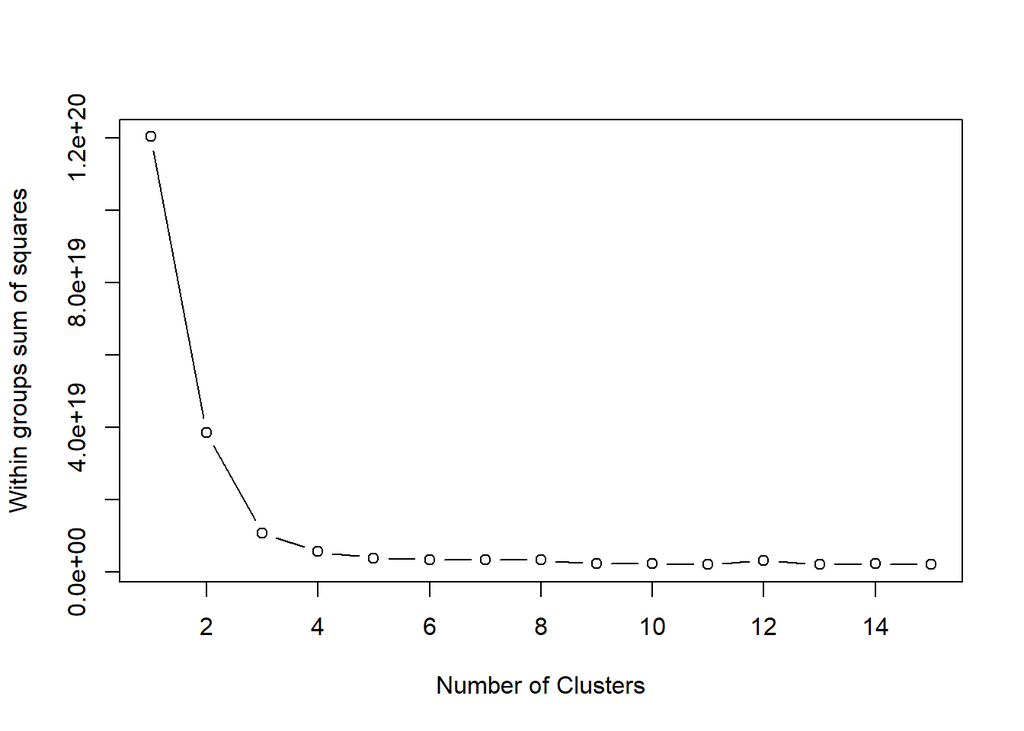

```r
wss <- (nrow(data.matrix(dataset)-1)*sum(apply(data.matrix(dataset),2,var)))
for (i in 2:15) wss[i] <- sum(kmeans(data.matrix(dataset),
                                     centers=i)$withinss)
plot(1:15, wss, type="b", xlab="Number of Clusters",
     ylab="Within groups sum of squares")
```

```r
# K-Means Cluster Analysis
fit <- kmeans(data.matrix(dataset), 5) # 5 cluster solution
# get cluster means
aggregate(data.matrix(dataset),by=list(fit$cluster),FUN=mean)
```

```
##   Group.1  airline avail_seat_km_per_week incidents_85_99
## 1       1 30.00000             2900260555        6.142857
## 2       2 28.16667              440409761        4.708333
## 3       3 28.00000             6297769175       21.333333
## 4       4 25.46154              908347103       10.000000
## 5       5 32.77778             1773923896        5.777778
##   fatal_accidents_85_99 fatalities_85_99 incidents_00_14
## 1              2.000000         44.42857        5.428571
## 2              1.458333         81.29167        2.125000
## 3              8.333333        275.66667       18.333333
## 4              2.307692        137.46154        4.153846
## 5              2.000000        157.66667        3.666667
##   fatal_accidents_00_14 fatalities_00_14
## 1             0.7142857         63.28571
## 2             0.5000000         25.16667
## 3             2.3333333        192.00000
## 4             0.6153846         93.30769
## 5             0.5555556         30.33333
```

```r
#Jouer sur les années entre 2000 et 2014
data00_14=dataset[,c(1,6,7,8)]
# append cluster assignment
mydata <- data.frame(data.matrix(data00_14), fit$cluster)
mydata
```

```
##    airline incidents_00_14 fatal_accidents_00_14 fatalities_00_14
## 1        1               0                     0                0
## 2        2               6                     1               88
## 3        3               1                     0                0
## 4        4               5                     0                0
## 5        5               2                     0                0
## 6        6               6                     2              337
## 7        7               4                     1              158
## 8        8               5                     1                7
## 9        9               5                     1               88
## 10      10               4                     0                0
## 11      11               7                     0                0
## 12      12              17                     3              416
## 13      13               1                     0                0
## 14      14               0                     0                0
```

[output cut: 99 more lines]

### Visualisation des accidents par airline entre 2000 et 2014

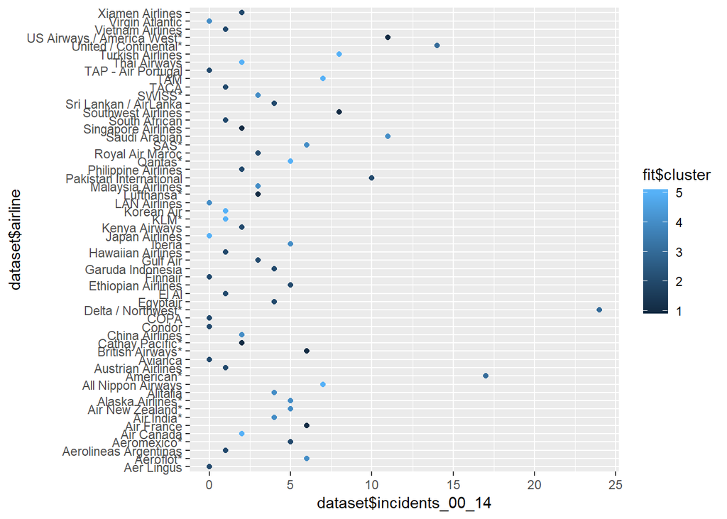

```r
library(ggplot2)
ggplot(dataset, aes(dataset$incidents_00_14,dataset$airline , color = fit$cluster)) + geom_point()
```

## Analyse de l’exigence Retards :

```r
library("tm")
```

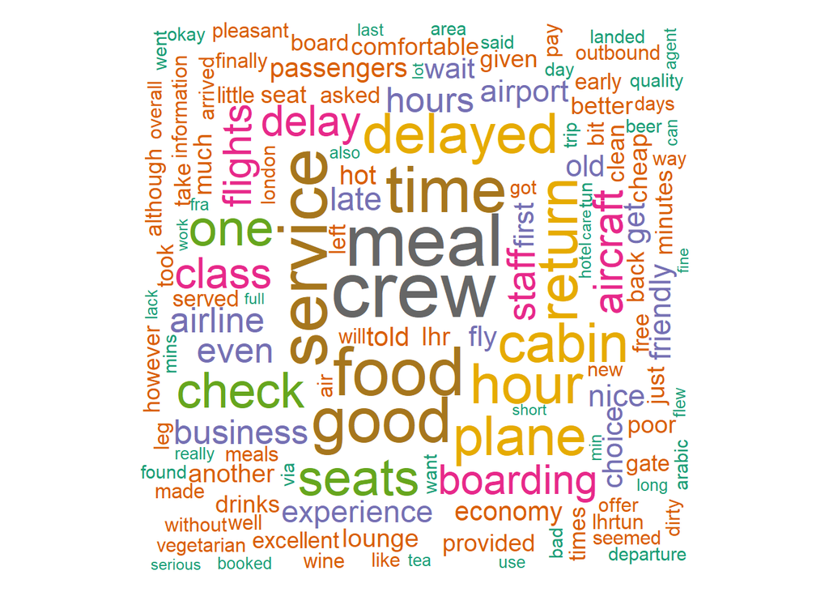

```r
library("SnowballC")
library("wordcloud")
library("RColorBrewer")

source('http://www.sthda.com/upload/rquery_wordcloud.r')
filePath <- "testcloud.txt"
res<-rquery.wordcloud(filePath, type ="file", lang = "english",excludeWords = c("flight","tunisair","tunis"))
```

```r
head(res$freqTable,20)
```

```
##              word freq
## crew         crew   49
## meal         meal   45
## service   service   42
## food         food   41
## time         time   39
## good         good   38
## hour         hour   33
## delayed   delayed   33
## cabin       cabin   32
## plane       plane   32
## return     return   32
## one           one   29
## seats       seats   29
## check       check   28
## delay       delay   23
## class       class   23
## boarding boarding   22
## aircraft aircraft   22
## flights   flights   21
## staff       staff   20
```

Le mot “delayed”-> “retard” apparait 33 fois dans les avis des utilisateurs scrappés. On peut constater que les voyageurs ont souffert des retards qui sont dues la plupart du temps à des problèmes techniques. Donc la flotte de TunisAir ne répond pas à l’exigence temps.

## Analyse des avis

```r
set.seed(123)
library(randomForest)
forest=randomForest(reviews.forest$overall~.,data = reviews.forest,na.action = na.omit)
```

Ici nous fixons la graine du générateur aléatoire . Nous lançons aprés randomForest qui est une methode d’apprentissage automatique supervisée . Nous laissons les paramétres par défauts pour les nombre d’arbres et de variables par arbre . Nous choisissons également dans un premier temps de ne pas prendre en compte les valeurs NA.

```r
print(forest)
```

```
##
## Call:
##  randomForest(formula = reviews.forest$overall ~ ., data = reviews.forest,      na.action = na.omit)
##                Type of random forest: classification
##                      Number of trees: 500
## No. of variables tried at each split: 2
##
##         OOB estimate of  error rate: 52.7%
## Confusion matrix:
##      1  2  3  4  5  6   7   8   9  10 class.error
## 1  534 46 32 17  7  6   4   3   3   2   0.1834862
## 2  156 59 41 23 12  4   7   1   0   1   0.8059211
## 3   93 46 63 20 32 10  16   5   0   0   0.7789474
## 4   30 34 36 40 29 17  16   6   5   1   0.8130841
## 5    9 18 38 19 53 35  32  16   4   2   0.7654867
## 6    2  9 10 11 39 44  47  30  14   1   0.7874396
## 7    1  4 11  4 19 27 106 101  41  10   0.6728395
## 8    3  2  1  4  7 15  59 185 186  39   0.6307385
## 9    1  0  1  0  1  2  17 109 314 188   0.5039494
## 10   0  0  0  1  0  1   2  16 166 519   0.2638298
```

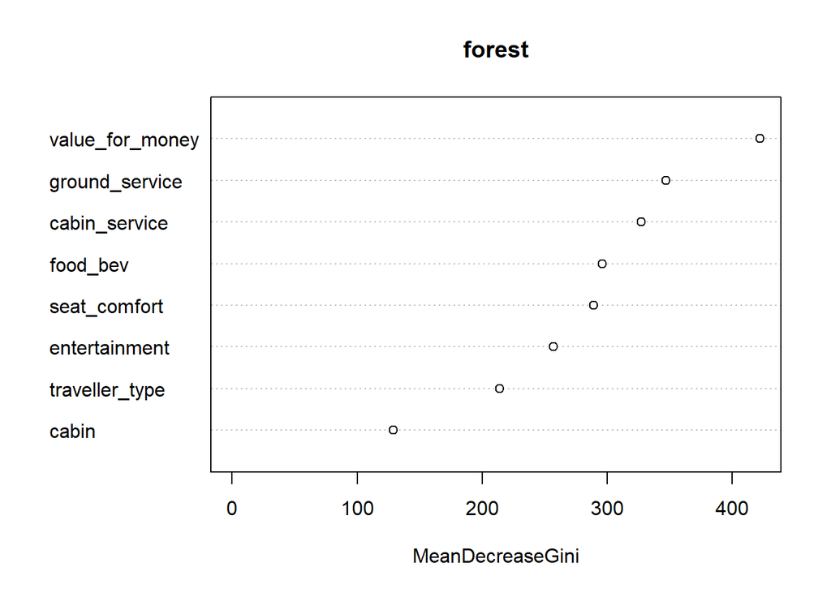

```r
varImpPlot(forest)
```

```r
forest1=randomForest(reviews.forest$overall~.,data = reviews.forest,na.action = na.roughfix)
print(forest1)
```

```
##
## Call:
##  randomForest(formula = reviews.forest$overall ~ ., data = reviews.forest,      na.action = na.roughfix)
##                Type of random forest: classification
##                      Number of trees: 500
## No. of variables tried at each split: 2
##
##         OOB estimate of  error rate: 53.07%
## Confusion matrix:
##       1   2   3  4   5  6   7   8   9  10 class.error
## 1  1469  84  58 16  24  9   8  11   9  44   0.1518476
## 2   392 150  78 31  33  7  10  11   4   7   0.7925311
## 3   216 107 119 32  68 19  21  14   8   9   0.8058728
## 4    84  63  73 57  67 36  32  19  19  12   0.8766234
## 5    48  46  65 37 156 62  69  51  32   6   0.7272727
## 6    25  12  29 25  87 83 109  87  39   4   0.8340000
## 7     9  10  13 10  56 54 195 306 113  23   0.7528517
## 8     4   3   3  3  23 22 122 526 376  94   0.5527211
## 9     2   2   1  1   7  1  29 295 586 349   0.5396701
## 10    1   0   0  0   2  2   5  71 319 992   0.2873563
```

En affectant la valeur mediane aux valeur NA , nous n’avons pas pu amélioré le OOB qui a augmenté de 0.37%.

```r
forest2=randomForest(reviews.forest$overall~.,data=reviews.forest,na.action=na.omit,ntree = 5000)
print(forest2)
```

```
##
## Call:
##  randomForest(formula = reviews.forest$overall ~ ., data = reviews.forest,      ntree = 5000, na.action = na.omit)
##                Type of random forest: classification
##                      Number of trees: 5000
## No. of variables tried at each split: 2
##
##         OOB estimate of  error rate: 52.08%
## Confusion matrix:
##      1  2  3  4  5  6   7   8   9  10 class.error
## 1  543 37 38 11  8  5   4   3   3   2   0.1697248
## 2  158 59 42 21 13  4   4   1   0   2   0.8059211
## 3   98 38 66 28 29  9  13   4   0   0   0.7684211
## 4   27 33 44 37 27 19  15   6   5   1   0.8271028
## 5    9 17 37 23 55 29  35  15   4   2   0.7566372
## 6    2  6 14 14 34 41  49  32  14   1   0.8019324
## 7    1  2 10  5 19 28 107 104  38  10   0.6697531
## 8    5  2  0  3 10 15  53 194 181  38   0.6127745
## 9    2  0  0  0  1  0  18 104 322 186   0.4913112
## 10   0  0  0  0  1  1   2  18 165 518   0.2652482
```

En augmentant le nombre d’arbres , nous avons pu ameliorer le OOB qui a legerement diminué .

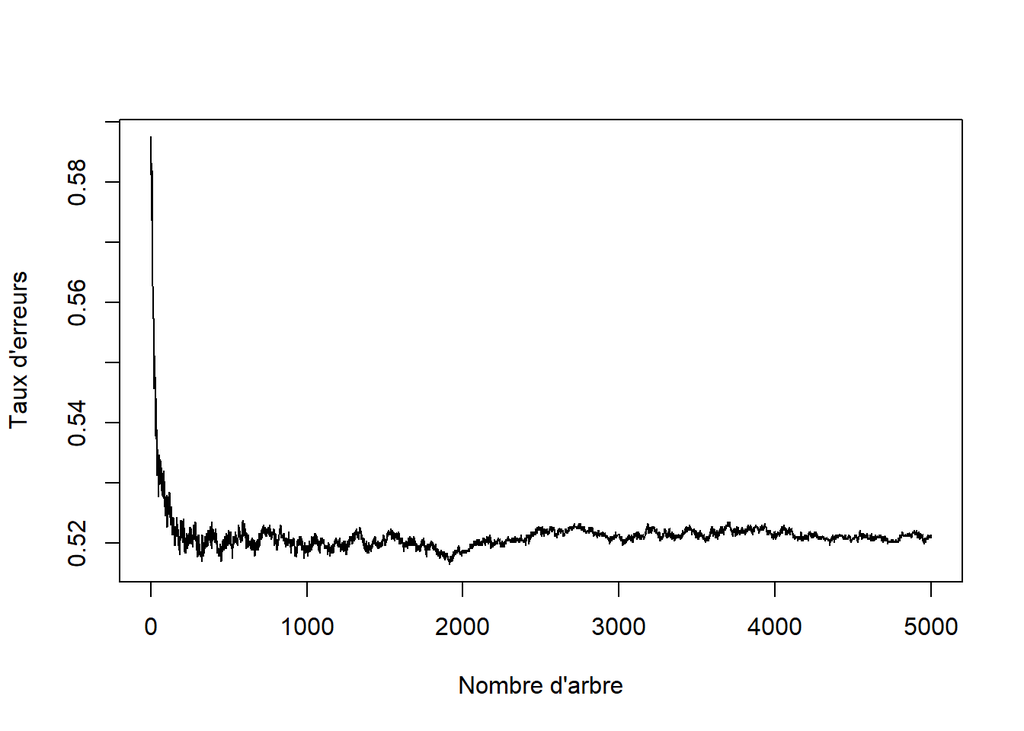

```r
plot(forest2$err.rate[,1],type='l',xlab="Nombre d'arbre",ylab="Taux d'erreurs")
```

```r
res=c()
res[1]=forest2$err.rate[1200]
for (i in 3:10){
  forest2=randomForest(reviews.forest$overall~.,data=reviews.forest,mtry=i,ntree=1200,na.action = na.omit)
  res[i-1]=forest2$err.rate[1200]
}
```